# Exploratory and Univariant Analysis of Customer Table Last 30 Variables

# **Author:** Chimdia Kabuo

# **Supervisor:** Alessandro Selvitella

### Install Packages

```r
# Save current warning behavior
old_warning <- getOption("warn")

# Temporarily suppress warnings
options(warn = -1)

install.packages('reshape2')
install.packages('car')

# Restore original warning behavior
options(warn = old_warning)
```

### Load Packages

```r
library(lubridate)
library(tidyverse)
library(ggplot2)
library(reshape2)
library(car)
library(dplyr)

cat("Done")
```

```
Done
```

### Function | Clean Data |

```r
## remove leading/trailing white space, convert blank cells to NA, convert POSIX object to Date, and convert from character to numeric where appropriate
Clean_Data_fx <- function(df1){
  ## Convert blanks to NA. Need to do this outside of dtplyr to recover type
  df1 <- map_df(df1, function(x){
    # Everything will be convert to character type. Capture the type to later convert back
    Type_use <- switch(match(typeof(x), c("logical", "integer", "double", "character")),
                       as.logical,
                       as.integer,
                       as.double,
                       as.character)

    Convert <- map_lgl(class(x), function(y){
      y %in% c("POSIXct", "POSIXt", "Date")
    })

    if(any(Convert)){
      return(as.Date(x))

    }else if(typeof(x) == "character"){
      return(tryCatch(type.convert(Type_use(gsub("^$", NA, trimws(x))), as.is = TRUE), error = function(e) x))

    }else{
      return(tryCatch(type.convert(Type_use(gsub("^$", NA, x)), as.is = TRUE), error = function(e) x))
    }

  })

  df1 <- df1 %>% mutate(across(where(is.factor), ~ as.character(.x)))

  return(df1)

}
```

### Function | Get Eligible Population |

```r
## 3 months from end of August. Used to determine eligible members and checking and savings accounts
Startdate <- as.Date("2023-06-01", origin = "1970-01-01")


## Start with customer data to determine elgibility then look at account data
df_Cust <- readRDS('/home/x-ckabuo/corporate/3rivers-membership/projects/x-ckabuo/data/Customer_Table.rds')

## active member from at least June 1st 2023 and is currently active the customer type is "Personal" and the member is at least 18 years old
ID_use <- df_Cust %>%
  Clean_Data_fx(.) %>%          ## this is a self-written function to clean the data
  filter(datejoined < Startdate,
         isactive == "Yes",
         type == "Personal",
         age >= 18) %>%
  pull(id)

## read in customer to account table
df_CtA <- readRDS('/home/x-ckabuo/corporate/3rivers-membership/projects/x-ckabuo/data/CustomerToAccount_Table.rds')

## member needs to have an active checking or savings account that was opened before June 1st.
# Doesn't matter if they are the primary on the account. Use the customer to account table because the account table will only have primary member
df_Population <- df_CtA %>%
  filter(application %in% c("CH", "SV")) %>%
  Clean_Data_fx(.) %>%                          ## this is a self-written function to clean the data
  filter(customerid %in% ID_use,
         startdatetime < Startdate,
         isactive == "Yes") %>%
  mutate(accountid = as.character(accountid)) ## make account id a string instead of a number


## read in account table. Need the  product market field
df_Acct <- readRDS('/home/x-ckabuo/corporate/3rivers-membership/projects/x-ckabuo/data/Account_Table.rds')

## last step is to check whether any of the checking or saving accounts are "Consumer". If not then drop
df_Population  <- df_Acct %>%
  select(number, productmarket, productname) %>%
  left_join(df_Population, ., by = c("accountid" = "number")) %>%
  filter(is.na(productmarket == "Consumer") | productmarket == "Consumer",  ## some productmarket labels are missing which would count as "Consumer"
         productname != "Business Money Market") %>%                        #  except "Business Money Market"
  distinct(customerid)   ## only want unique customer id.

  ## Need Secondary_ID to identify other memberships of the member. We will want to use that data for the member
df_Population <- df_Cust %>%
  select(customerid = id, Secondary_ID) %>%
  filter(customerid %in% df_Population$customerid) %>%
  mutate(Secondary_ID = ifelse(is.na(Secondary_ID), customerid, Secondary_ID)) ## assigned customerid when secondary is missing to filter when merging

#saveRDS(df_Population, file.path(myPaths$output, "Eligible_Members.rds"))
write.csv(df_Population, file ='/home/x-ckabuo/corporate/3rivers-membership/projects/x-ckabuo/prime/Eligible_Members2.csv')

cat("Done")
```

```
Done
```

### Select Data Variables

Select Last 29 Data Variables plus "id" From Customer Table

```r
#### ---------- Select 30 Data Variables From Customer Table---------- ####
VarsCust <- df_Cust[c('id','isactive','isdeceased','mortgagesprincipalbalance','numberofcreditcards','numberofdebitcards','numberofaccounts','numberofautoloans','numberofcdaccounts','numberofcheckingaccounts','numberofhomeequityloans','numberofloans','numberofmortgages','numberofsavingsaccounts','primarysharebranch','state','status','totalloansprincipalbalance','transactionamount_last30','transactioncount_last30','type','Online_user_status','Online_user_type','Online_user_create_dt','Online_last_login_dt','Online_last_app_login_dt','censuscode','HH_Number','RFG_Consumer_Segmint','Secondary_ID')]

cat("Done")
```

```
Done
```

#### Check dimensions, length and view data of the first 6 rows of the selected variables

```r
dim(VarsCust)
length(VarsCust)
head(VarsCust)
```

1. 331815

2. 30

30

A data.frame: 6 x 30

|  | id <chr> | isactive <chr> | isdeceased <chr> | mortgagesprincipalbalance <dbl> | numberofcreditcards <dbl> | numberofdebitcards <dbl> | numberofaccounts <dbl> | numberofautoloans <dbl> | numberofcdaccounts <dbl> | numberofcheckingaccounts <dbl> | ... | type <chr> | Online_user_status <chr> | Online_user_type <chr> | Online_user_create_dt <date> | Online_last_login_dt <date> | Online_last_app_login_dt <date> | censuscode <chr> | HH_Number <int> | RFG_Consumer_Segmint <chr> | Secondary_ID <chr> |
| --- | --- | --- | --- | --- | --- | --- | --- | --- | --- | --- | --- | --- | --- | --- | --- | --- | --- | --- | --- | --- | --- |
| 1 | P | NA | NA | NA | NA | NA | NA | NA | NA | NA | ... | Personal | NA | NA | NA | NA | NA | NA | NA | NA | NA |
| 2 | O582 | NA | NA | NA | NA | NA | NA | NA | NA | NA | ... | NA | NA | NA | NA | NA | NA | NA | NA | NA | NA |
| 3 | O717 | No | No | NA | NA | NA | NA | NA | NA | NA | ... | NA | NA | NA | NA | NA | NA | MUX7083416 | NA | NA | NA |
| 4 | O79185 | NA | NA | NA | NA | NA | NA | NA | NA | NA | ... | NA | NA | NA | NA | NA | NA | NA | NA | NA | NA |
| 5 | O404 | No | No | NA | NA | NA | NA | NA | NA | NA | ... | Non-Personal | NA | NA | NA | NA | NA | NA | NA | NA | NA |
| 6 | O418 | No | No | NA | NA | NA | NA | NA | NA | NA | ... | Non-Personal | NA | NA | NA | NA | NA | NA | NA | NA | NA |

### Intersect Selected Data Variables

Intersect selected data variables from eligible population

```r
I5=intersect(VarsCust['id'][,1], df_Population['customerid'][,1])
```

Check length of the intersect

```r
length(I5)
```

127217

### Check Number of Unique Rows

```r
row_index5<-c()
for (j in 1:length(I5)) {
row_index5<-c(row_index5,which(VarsCust['id'] == I5[j]))
}
row_index5<-unique(row_index5)
head(row_index5)
```

1. 166

2. 169

3. 171

4. 172

5. 173

6. 174

Create data frame to hold data of the selected variables based on the indices specidfied in `row_index5`.

```r
df_Cust_5 <- VarsCust[row_index5,]
```

Display dimensions of the data frame

```r
dim(df_Cust_5)
```

1. 127217

2. 30

Display first 6 rows of the `df_Cust_5` data frame for a quick overview

```r
head(df_Cust_5)
```

A data.frame: 6 x 30

|  | id <chr> | isactive <chr> | isdeceased <chr> | mortgagesprincipalbalance <dbl> | numberofcreditcards <dbl> | numberofdebitcards <dbl> | numberofaccounts <dbl> | numberofautoloans <dbl> | numberofcdaccounts <dbl> | numberofcheckingaccounts <dbl> | ... | type <chr> | Online_user_status <chr> | Online_user_type <chr> | Online_user_create_dt <date> | Online_last_login_dt <date> | Online_last_app_login_dt <date> | censuscode <chr> | HH_Number <int> | RFG_Consumer_Segmint <chr> | Secondary_ID <chr> |
| --- | --- | --- | --- | --- | --- | --- | --- | --- | --- | --- | --- | --- | --- | --- | --- | --- | --- | --- | --- | --- | --- |
| 166 | P15225 | Yes | No | 0.0 | 0 | 1 | 6 | 0 | 0 | 1 | ... | Personal | Active | Retail | 2021-09-15 | 2023-08-30 | 2023-01-26 | KZH8716593 | 851940 | Credit Driven (ConSeg) | PWTX218573904 |
| 169 | P15256 | Yes | No | 0.0 | 1 | 1 | 3 | 0 | 0 | 1 | ... | Personal | NA | NA | NA | NA | NA | WEH9207846 | 42211 | Upscale (ConSeg) | KCVN263985417 |
| 171 | P15293 | Yes | No | 0.0 | 0 | 1 | 5 | 1 | 0 | 1 | ... | Personal | Active | Retail | 2021-09-15 | 2023-08-31 | 2023-08-31 | RXI1527049 | 210778 | Fee Driven (ConSeg) | GQMC057948123 |
| 172 | P15322 | Yes | No | 0.0 | 0 | 0 | 1 | 0 | 0 | 0 | ... | Personal | NA | NA | NA | NA | NA | USP9031845 | NA | NA | CUGW096275483 |
| 173 | P15325 | Yes | No | 0.0 | 0 | 0 | 2 | 0 | 0 | 1 | ... | Personal | NA | NA | NA | NA | NA | BLY4053298 | 16616 | Upscale (ConSeg) | ZXCW164297035 |
| 174 | P15326 | Yes | No | 152996.2 | 0 | 1 | 13 | 1 | 2 | 4 | ... | Personal | Active | Retail | 2021-09-15 | 2023-08-31 | 2023-08-31 | QCW9405316 | 3170 | Middle Market (ConSeg) | ZGQE495102673 |

#### Generate descriptive statistics for each column in the `df_Cust_5` data frame.

```r
summary(df_Cust_5)
```

```
      id              isactive          isdeceased
 Length:127217      Length:127217      Length:127217
 Class :character   Class :character   Class :character
 Mode  :character   Mode  :character   Mode  :character




 mortgagesprincipalbalance numberofcreditcards numberofdebitcards
 Min.   :      0           Min.   :0.000       Min.   : 0.000
 1st Qu.:      0           1st Qu.:0.000       1st Qu.: 0.000
 Median :      0           Median :0.000       Median : 1.000
 Mean   :  23672           Mean   :0.194       Mean   : 1.165
 3rd Qu.:      0           3rd Qu.:0.000       3rd Qu.: 2.000
 Max.   :3658759           Max.   :9.000       Max.   :31.000
                           NA's   :9719        NA's   :9719
 numberofaccounts numberofautoloans numberofcdaccounts numberofcheckingaccounts
 Min.   : 1.000   Min.   : 0.0000   Min.   : 0.0000    Min.   : 0.000
 1st Qu.: 2.000   1st Qu.: 0.0000   1st Qu.: 0.0000    1st Qu.: 0.000
 Median : 2.000   Median : 0.0000   Median : 0.0000    Median : 1.000
 Mean   : 3.278   Mean   : 0.2032   Mean   : 0.1102    Mean   : 1.041
 3rd Qu.: 4.000   3rd Qu.: 0.0000   3rd Qu.: 0.0000    3rd Qu.: 1.000
 Max.   :63.000   Max.   :19.0000   Max.   :39.0000    Max.   :23.000

 numberofhomeequityloans numberofloans     numberofmortgages
 Min.   :0.00000         Min.   : 0.0000   Min.   :0.0000
 1st Qu.:0.00000         1st Qu.: 0.0000   1st Qu.:0.0000
 Median :0.00000         Median : 0.0000   Median :0.0000
 Mean   :0.04495         Mean   : 0.5176   Mean   :0.1436
 3rd Qu.:0.00000         3rd Qu.: 1.0000   3rd Qu.:0.0000
 Max.   :2.00000         Max.   :24.0000   Max.   :8.0000

 numberofsavingsaccounts primarysharebranch    state
 Min.   : 0.000          Length:127217      Length:127217
 1st Qu.: 1.000          Class :character   Class :character
 Median : 1.000          Mode  :character   Mode  :character
 Mean   : 1.335
 3rd Qu.: 2.000
 Max.   :23.000

```

[output cut: 21 more lines]

```
                    3rd Qu.:2021-09-16    3rd Qu.:2023-08-31
                    Max.   :2023-08-31    Max.   :2023-08-31
                    NA's   :58795         NA's   :59161
 Online_last_app_login_dt  censuscode          HH_Number
 Min.   :2021-09-22       Length:127217      Min.   :      1
 1st Qu.:2023-08-22       Class :character   1st Qu.:  25207
 Median :2023-08-30       Mode  :character   Median : 262718
 Mean   :2023-08-06                          Mean   :1007014
 3rd Qu.:2023-08-31                          3rd Qu.:1762112
 Max.   :2023-08-31                          Max.   :4618371
 NA's   :69641                               NA's   :36715
 RFG_Consumer_Segmint Secondary_ID
 Length:127217        Length:127217
 Class :character     Class :character
 Mode  :character     Mode  :character
```

### Extract Numeric Columns from the Selected Data variables

```r
##**** Identify numeric columns ****##
numCols <- unlist(lapply(VarsCust, is.numeric))

##**** Print Subset of Numeric Columns ****##
CustNum <- VarsCust[, numCols]
```

Return names of the columns in the numerical data frame

```r
names(CustNum)
```

1. 'mortgagesprincipalbalance'

2. 'numberofcreditcards'

3. 'numberofdebitcards'

4. 'numberofaccounts'

5. 'numberofautoloans'

6. 'numberofcdaccounts'

7. 'numberofcheckingaccounts'

8. 'numberofhomeequityloans'

9. 'numberofloans'

10. 'numberofmortgages'

11. 'numberofsavingsaccounts'

12. 'totalloansprincipalbalance'

13. 'transactionamount_last30'

14. 'transactioncount_last30'

15. 'HH_Number'

Return dimensions of the numerical data frame

```r
dim(CustNum)
```

1. 331815

2. 15

#### Generate descriptive statistics for each column in the `CustNum` data frame.

```r
summary(CustNum)
```

```
 mortgagesprincipalbalance numberofcreditcards numberofdebitcards
 Min.   :      0           Min.   :0.00        Min.   : 0.00
 1st Qu.:      0           1st Qu.:0.00        1st Qu.: 0.00
 Median :      0           Median :0.00        Median : 0.00
 Mean   :   9783           Mean   :0.09        Mean   : 0.59
 3rd Qu.:      0           3rd Qu.:0.00        3rd Qu.: 1.00
 Max.   :3658759           Max.   :9.00        Max.   :31.00
 NA's   :14384             NA's   :63086       NA's   :63086
 numberofaccounts  numberofautoloans numberofcdaccounts
 Min.   :  0.000   Min.   : 0.000    Min.   : 0.000
 1st Qu.:  0.000   1st Qu.: 0.000    1st Qu.: 0.000
 Median :  0.000   Median : 0.000    Median : 0.000
 Mean   :  1.452   Mean   : 0.088    Mean   : 0.056
 3rd Qu.:  2.000   3rd Qu.: 0.000    3rd Qu.: 0.000
 Max.   :121.000   Max.   :20.000    Max.   :39.000
 NA's   :14384     NA's   :14384     NA's   :14384
 numberofcheckingaccounts numberofhomeequityloans numberofloans
 Min.   : 0.000           Min.   :0.000           Min.   : 0.000
 1st Qu.: 0.000           1st Qu.:0.000           1st Qu.: 0.000
 Median : 0.000           Median :0.000           Median : 0.000
 Mean   : 0.464           Mean   :0.018           Mean   : 0.224
 3rd Qu.: 1.000           3rd Qu.:0.000           3rd Qu.: 0.000
 Max.   :25.000           Max.   :2.000           Max.   :36.000
 NA's   :14384            NA's   :14384           NA's   :14384
 numberofmortgages numberofsavingsaccounts totalloansprincipalbalance
 Min.   :0.00      Min.   : 0.00           Min.   :   -4576
 1st Qu.:0.00      1st Qu.: 0.00           1st Qu.:       0
 Median :0.00      Median : 0.00           Median :       0
 Mean   :0.06      Mean   : 0.59           Mean   :    5563
 3rd Qu.:0.00      3rd Qu.: 1.00           3rd Qu.:       0
 Max.   :8.00      Max.   :23.00           Max.   :25306359
 NA's   :14384     NA's   :14384           NA's   :14384
 transactionamount_last30 transactioncount_last30   HH_Number
 Min.   :-26785829        Min.   :    0.00        Min.   :      1
 1st Qu.:     -101        1st Qu.:    1.00        1st Qu.:  25973
 Median :        0        Median :    5.00        Median : 289291
 Mean   :     -491        Mean   :   28.82        Mean   :1054672
 3rd Qu.:      250        3rd Qu.:   41.00        3rd Qu.:1767536
 Max.   :  4072812        Max.   :19345.00        Max.   :4618371
 NA's   :185999           NA's   :185999          NA's   :222536
```

#### Generate a set of boxplots for each variable in the `Custnum` data frame

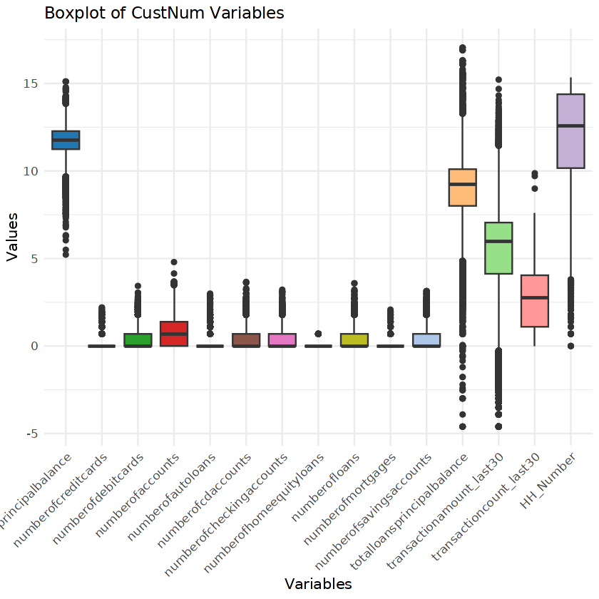

```r
# Save current warning behavior
old_warning <- getOption("warn")

# Temporarily suppress warnings
options(warn = -1)

# Melt the data into long format
melted_data <- reshape2::melt(CustNum)

# Create a custom color palette
my_colors <- c("#1f77b4", "#ff7f0e", "#2ca02c", "#d62728", "#9467bd",
               "#8c564b", "#e377c2", "#7f7f7f", "#bcbd22", "#17becf",
               "#aec7e8", "#ffbb78", "#98df8a", "#ff9896", "#c5b0d5")

# Create a boxplot for each column with custom colors
ggplot(melted_data, aes(x = variable, y = log(value), fill = variable)) +
  geom_boxplot() +
  scale_fill_manual(values = my_colors) +
  theme_minimal() +
  theme(axis.text.x = element_text(angle = 45, hjust = 1),
        legend.position = "none",
        panel.spacing = unit(0.5, "lines"),
        strip.text = element_text(face = "bold"),
        axis.text = element_text(size = 10),
        axis.title = element_text(size = 12)) +
  labs(title = "Boxplot of CustNum Variables",
       x = "Variables",
       y = "Values")

# Restore original warning behavior
options(warn = old_warning)
```

#### Generate histograms for each numeric variable in `CustNum` data frame | Using the data frame and column name

`scale_x_log10` is used to scale the x-axis logarithmically for better visualization of highly skewed data.

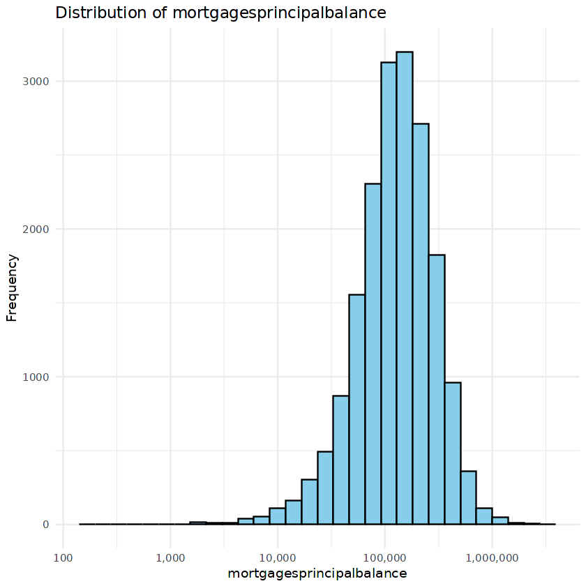

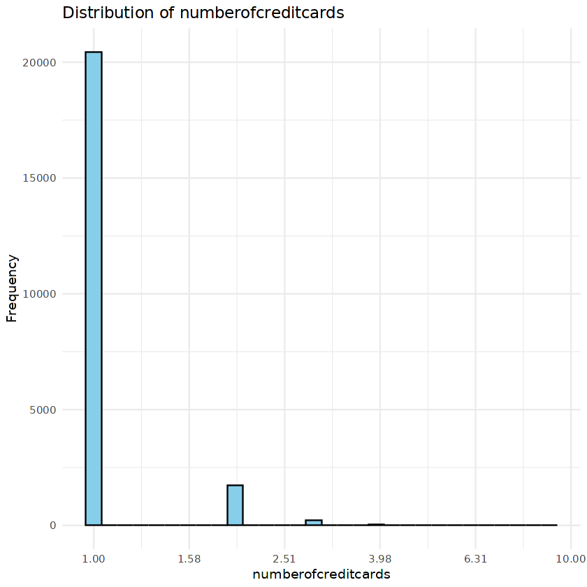

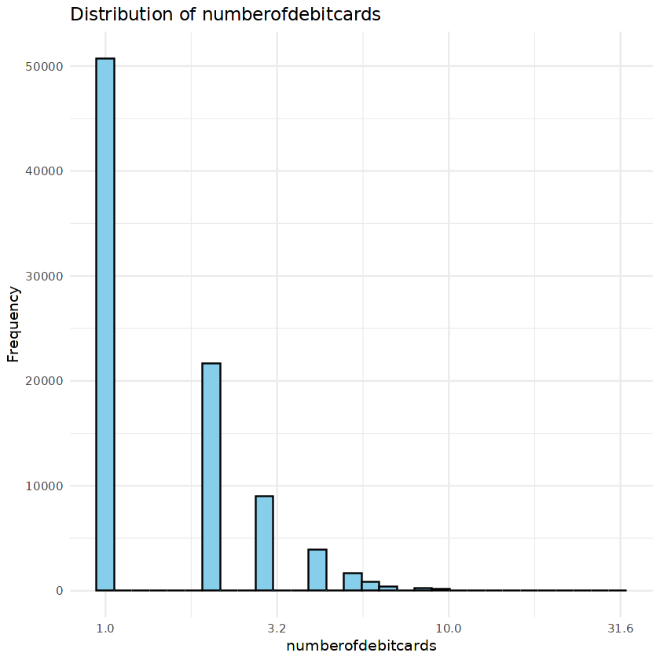

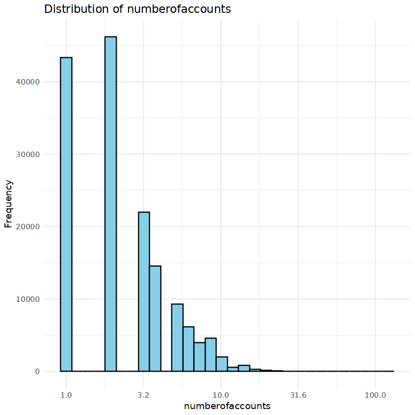

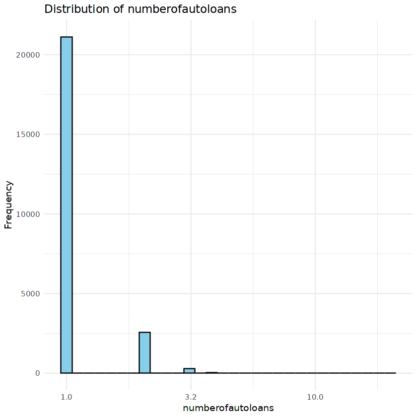

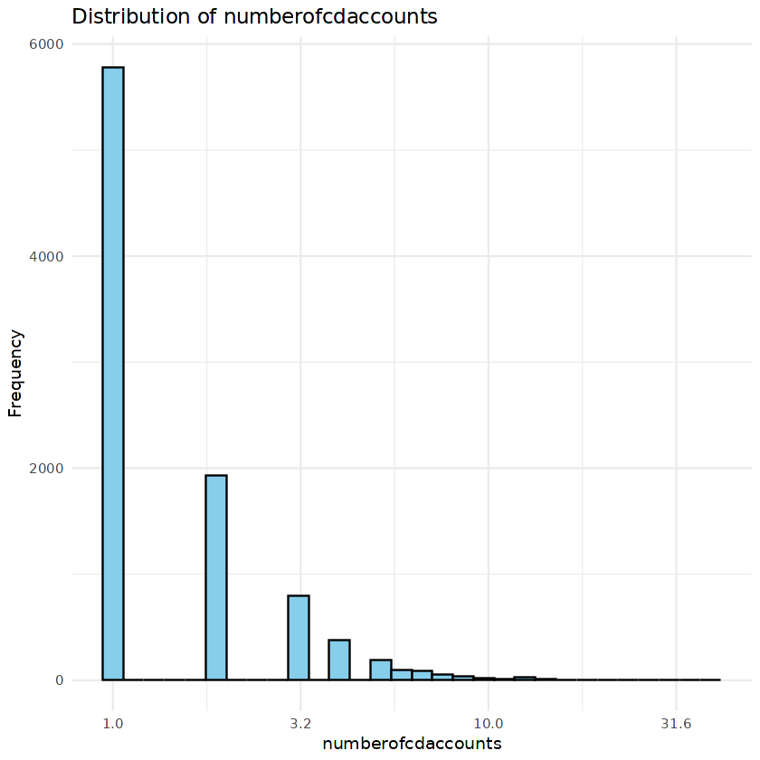

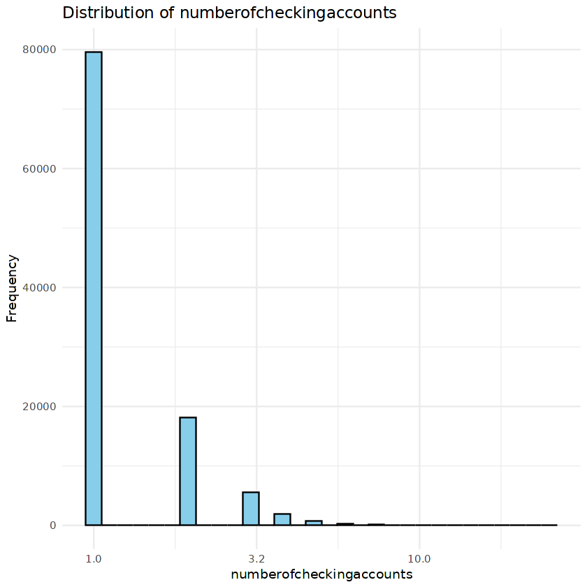

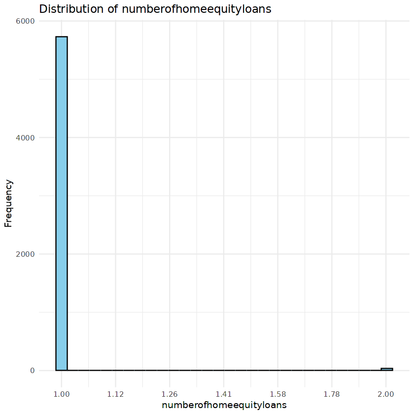

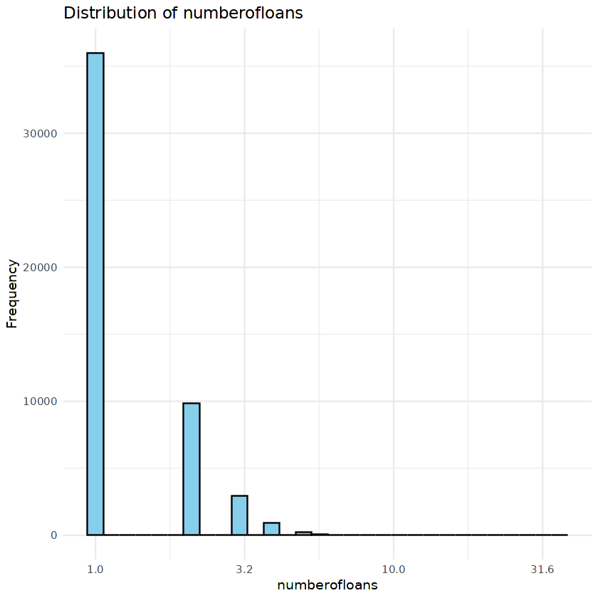

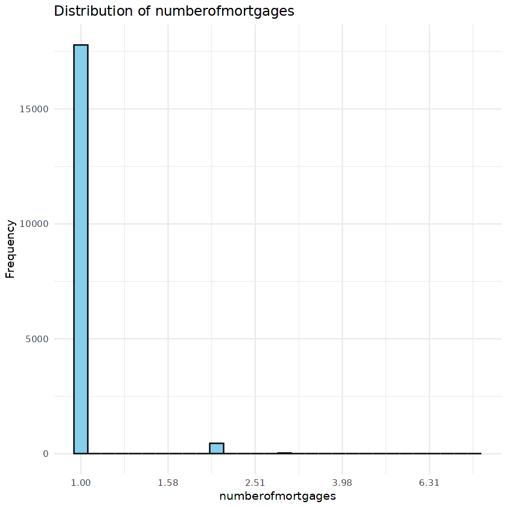

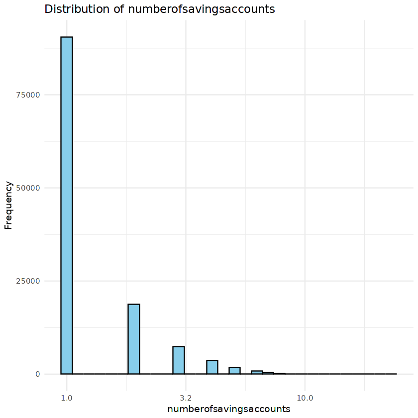

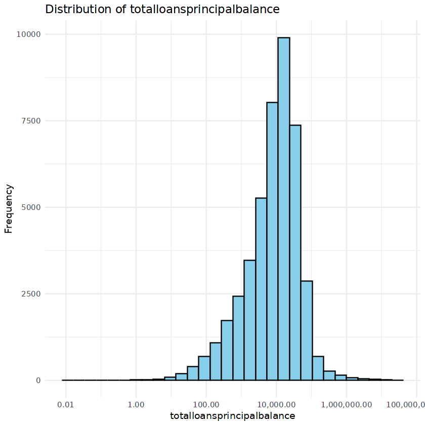

[3 more figures not shown]

```r
# Save current warning behavior
old_warning <- getOption("warn")

# Temporarily suppress warnings
options(warn = -1)

# Create a function to generate histograms for numeric variables
plot_numeric <- function(data, column_name) {
  ggplot(data, aes(x = .data[[column_name]])) +
    geom_histogram(fill = "skyblue", color = "black", bins = 30) +
    scale_x_log10(labels = scales::comma, breaks = scales::trans_breaks("log10", function(x) 10^x)) +
    labs(title = paste("Distribution of", column_name),
         x = column_name,
         y = "Frequency") +
    theme_minimal()
}

# Loop through each column in CustNum and plot its distribution
for (col in names(CustNum)) {
  print(plot_numeric(CustNum, col))
}

# Restore original warning behavior                                                                        # Restore original warning behavior# Restore original warning behavior
options(warn = old_warning)
```

#### Generate histogram for 'numberofsavingsaccounts' column of the `Custnum` data frame plotted against Frequency

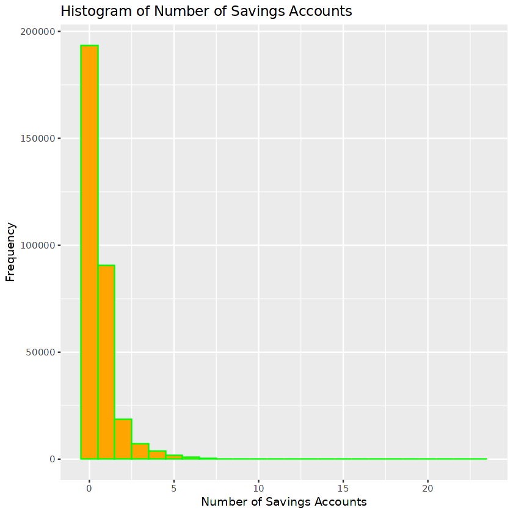

```r
# Save current warning behavior
old_warning <- getOption("warn")

# Temporarily suppress warnings
options(warn = -1)

# Histogram for numberofsavingsaccounts
ggplot(CustNum, aes(x = numberofsavingsaccounts)) +
  geom_histogram(binwidth = 1, fill = "orange", color = "green") +
  labs(title = "Histogram of Number of Savings Accounts",
       x = "Number of Savings Accounts",
       y = "Frequency")

options(warn = old_warning)
```

#### Extract Categorical Columns from the Selected variables

```r
##**** Identify categorical columns ****##
cateCols <- sapply(VarsCust, function(x) !is.numeric(x))

##**** Print Subset of categorical Columns ****##
CustCate <- VarsCust[, cateCols]
```

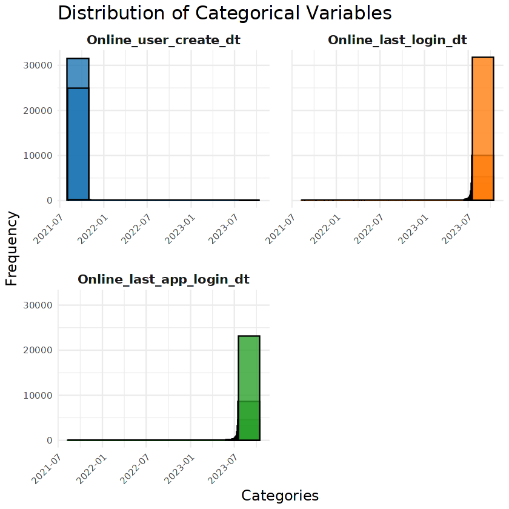

```r
# Save current warning behavior
old_warning <- getOption("warn")

# Temporarily suppress warnings
options(warn = -1)

# Melt the data into long format
melted_data <- melt(CustCate)

# Create a custom color palette
my_colors <- c("#1f77b4", "#ff7f0e", "#2ca02c", "#d62728", "#9467bd", "#8c564b", "#e377c2", "#7f7f7f", "#bcbd22", "#17becf")

# Create a bar plot for each categorical variable
ggplot(melted_data, aes(x = value, fill = variable)) +
  geom_bar(color = "black", position = "dodge", alpha = 0.8, width = 90) +
  facet_wrap(~ variable, scales = "free_x", nrow = 2) +
  labs(title = "Distribution of Categorical Variables",
       x = "Categories",
       y = "Frequency") +
  scale_fill_manual(values = my_colors) +
  theme_minimal() +
  theme(axis.text.x = element_text(angle = 45, hjust = 1),
        legend.position = "none",
        panel.spacing = unit(1.5, "lines"),  # Increase panel spacing
        strip.text.x = element_text(face = "bold", size = 12),  # Increase strip text size
        strip.background = element_blank(),  # Remove strip background
        plot.title = element_text(size = 18),  # Increase plot title size
        axis.title = element_text(size = 14))  # Increase axis label size

# Restore original warning behavior
options(warn = old_warning)
```

#### Analyze the relationship between Household numbers and the `numberofaccounts` | Sort the data and Plot a Line Graph

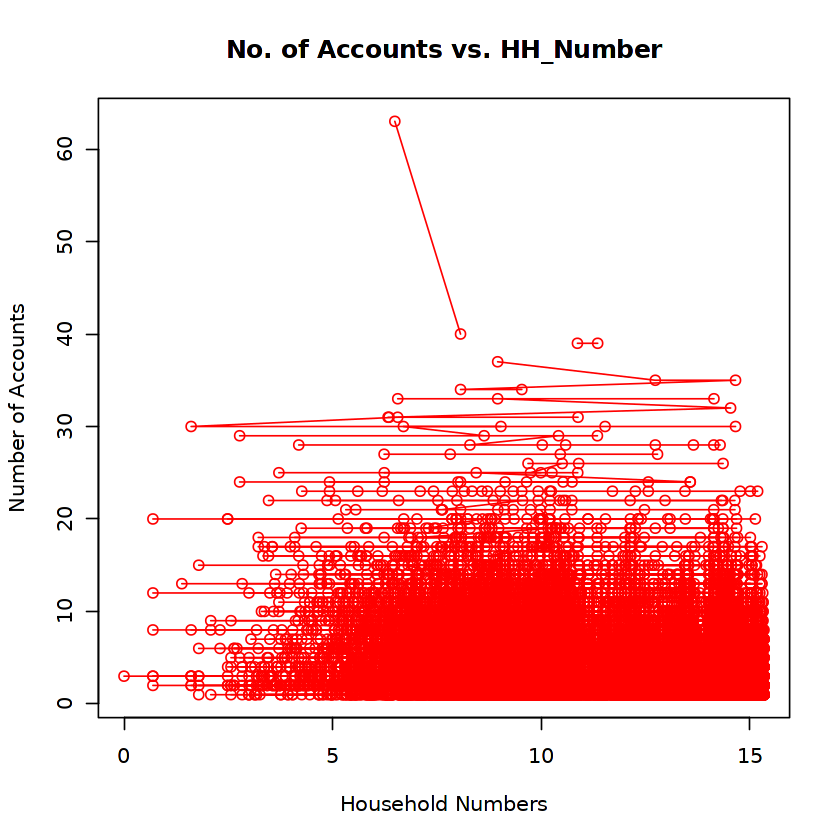

```r
# Relationship between Household numbers and number of accounts
df_Cust_sorted <- df_Cust_5[order(df_Cust_5$numberofaccounts), ]

# Line graph showing HH numbers vs. numberofaccounts
plot(log(df_Cust_sorted$HH_Number), df_Cust_sorted$numberofaccounts, type = "o", col = "red", xlab = "Household Numbers", ylab = "Number of Accounts", main = "No. of Accounts vs. HH_Number")
```

#### Plotting the trend of `numberofaccounts` over Household numbers

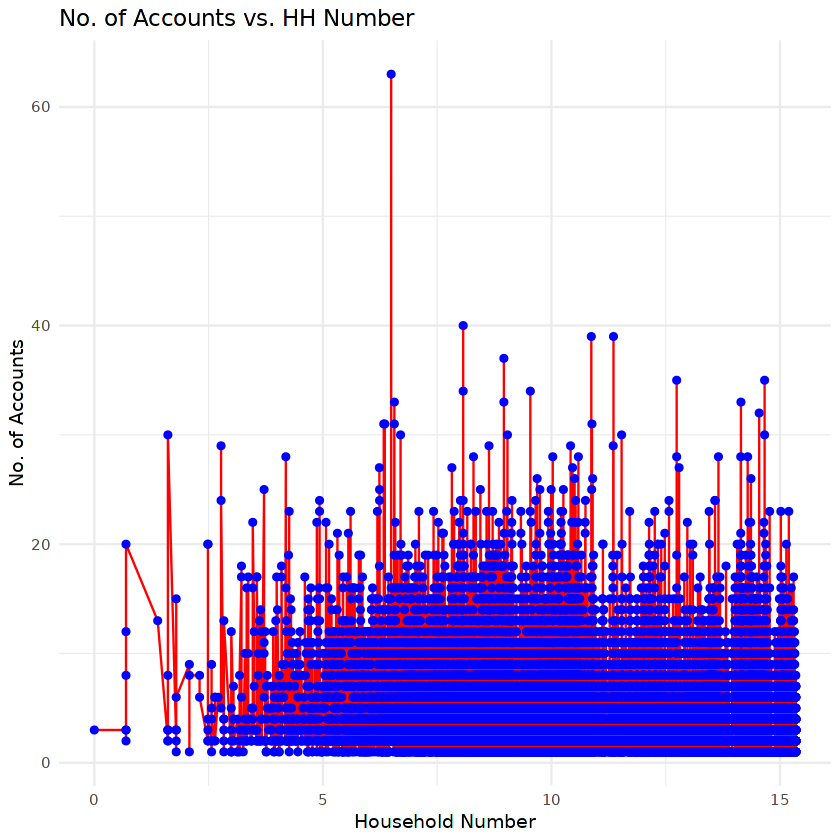

```r
# Save current warning behavior
old_warning <- getOption("warn")

# Temporarily suppress warnings
options(warn = -1)

## **** Plot the trend of numberofaccounts over Household numbers **** ##
ggplot(df_Cust_5, aes(x = log(HH_Number), y = numberofaccounts)) +
  geom_line(aes(group = 1), color = "red") +  # Ensure a single group for the line
  geom_point(color = "blue") +
  theme_minimal() +
  labs(title = "No. of Accounts vs. HH Number",
       x = "Household Number",
       y = "No. of Accounts")

# Restore original warning behavior
options(warn = old_warning)
```

```r
summary(df_Cust_5['numberofmortgages'])
```

```
 numberofmortgages
 Min.   :0.0000
 1st Qu.:0.0000
 Median :0.0000
 Mean   :0.1436
 3rd Qu.:0.0000
 Max.   :8.0000
```

#### Interpretation of summary(df_Cust_5['numberofmortgages'])

**Min.:** The minimum value of mortgages observed is zero.

**Max.:** The maximum value of mortgages observed is 8

**Mean:** The average value of mortgages calculated by summing up all values and dividing by the total number of observations is approximately "0.1436".

The rest are zeros

#### Summary

The avergae household has around 0.1436 mortgages

*Since the 1st quartile, the median, and the 3rd quartile are zero* - This means that 75% of the households have 0 mortgages.

### Discretize Numerical Columns of `CustNum` data frame and Store the Result in a new data frame `df_discretized`

```r
# Discretize numerical columns
df_discretized <- CustNum %>%
  mutate(
    numberofsavingsaccounts = cut(numberofsavingsaccounts, breaks = 3),  # Discretize into 3 bins
    numberofcreditcards_category = case_when(
      numberofcreditcards <= 1 ~ "Low",
      numberofcreditcards <= 3 ~ "Medium",
      TRUE ~ "High"
    ),
    numberofdebitcards_category = case_when(
      numberofdebitcards <= 1 ~ "Low",
      numberofdebitcards <= 3 ~ "Medium",
      TRUE ~ "High"
    )
  )

# View the discretized data
#print(df_discretized)
```

#### Perform frequency distributions test for three categorical variables in the `df_discretized` dataframe

```r
# Frequency distribution for numberofsavingsaccounts
freq_numberofsavingsaccounts <- table(df_discretized$numberofsavingsaccounts)
cat("Frequency distribution for numberofsavingsaccounts:")
print(freq_numberofsavingsaccounts)

# Frequency distribution for numberofcreditcards_category
freq_numberofcreditcards_category <- table(df_discretized$numberofcreditcards_category)
cat("\nFrequency distribution for numberofcreditcards_category:")
print(freq_numberofcreditcards_category)

# Frequency distribution for numberofdebitcards_category
freq_numberofdebitcards_category <- table(df_discretized$numberofdebitcards_category)
cat("\nFrequency distribution for numberofdebitcards_category:")
print(freq_numberofdebitcards_category)
```

```
Frequency distribution for numberofsavingsaccounts:
(-0.023,7.67]   (7.67,15.3]     (15.3,23]
       316869           542            20

Frequency distribution for numberofcreditcards_category:
  High    Low Medium
 63177 266689   1949

Frequency distribution for numberofdebitcards_category:
  High    Low Medium
 70479 230684  30652
```

#### Perfom Chi-squared tests to aasess association between two categorical variables in the `df_discretized` dataframe

```r
# Perform the chi-squared test
chisq_result <- chisq.test(df_discretized$numberofsavingsaccounts, CustNum$numberofloans)

# Print a formatted interpretation of the result
cat("Pearson's Chi-squared test:\n \n")
cat("Data:", names(df_discretized)[11], "and", names(CustNum)[9], "\n")
cat("X-squared =", round(chisq_result$statistic, 2), ", df =", chisq_result$parameter, ", p-value <", sprintf("%.4f", chisq_result$p.value), "\n") # Adjusted to display p-value in decimal notation with 4 decimal places
```

```
Pearson's Chi-squared test:

Data: numberofsavingsaccounts and numberofloans
X-squared = 1136.21 , df = 44 , p-value < 0.0000
```

## Interpretation

Since the p-value is extremely small (much smaller than any conventional significance level such as 0.05 or 0.01), we reject the null hypothesis. This means that the p-value is effectively zero (0)

### Summary:

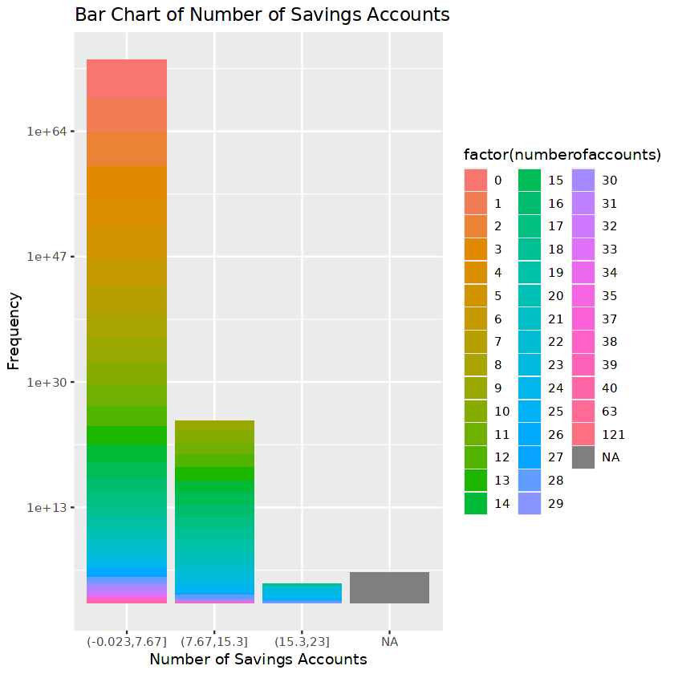

```r
# Bar chart for numberofsavingsaccounts
ggplot(df_discretized, aes((x = numberofsavingsaccounts), fill = factor(numberofaccounts))) +
  geom_bar() +
  labs(title = "Bar Chart of Number of Savings Accounts",
       x = "Number of Savings Accounts",
       y = "Frequency") + scale_y_log10()
```

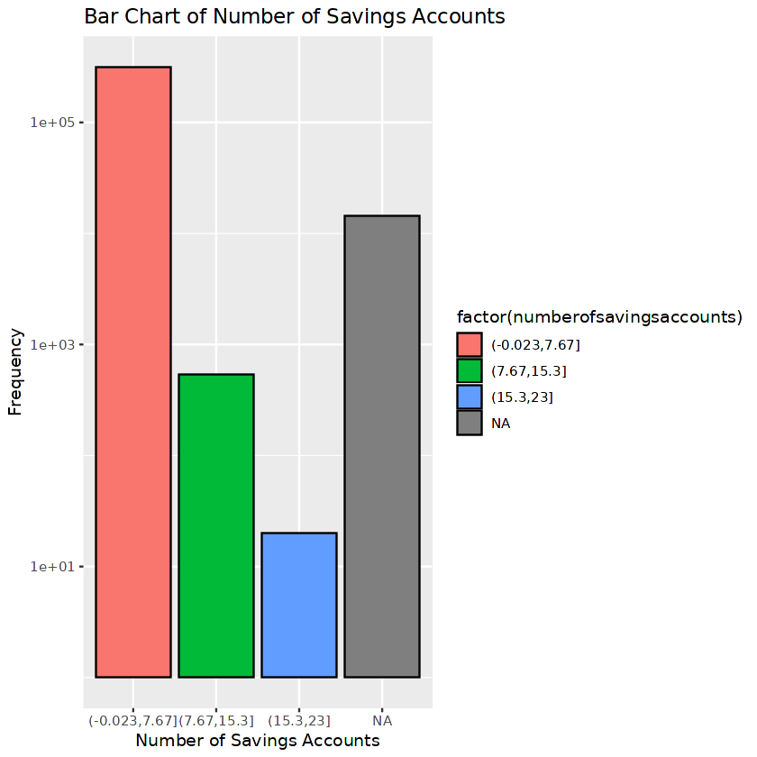

```r
# Bar chart for numberofsavingsaccounts with color for bars and log scale for frequency
ggplot(df_discretized, aes(x = numberofsavingsaccounts, fill = factor(numberofsavingsaccounts))) +
  geom_bar(color = "black") +  # Specify outline color for bars
  labs(title = "Bar Chart of Number of Savings Accounts",
       x = "Number of Savings Accounts",
       y = "Frequency") +
  scale_y_log10()  # Use logarithmic scale for the y-axis
```

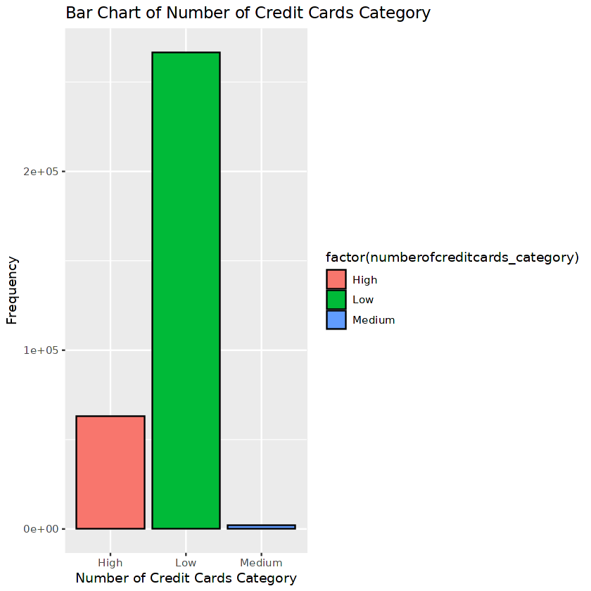

```r
# Bar chart for numberofcreditcards_category
ggplot(df_discretized, aes((x = numberofcreditcards_category), fill = factor(numberofcreditcards_category))) +
  geom_bar(color = "black") +
  labs(title = "Bar Chart of Number of Credit Cards Category",
       x = "Number of Credit Cards Category",
       y = "Frequency")
```

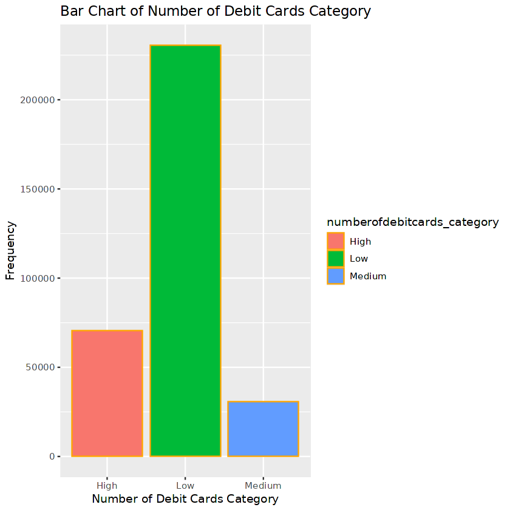

```r
# Bar chart for numberofdebitcards_category
ggplot(df_discretized, aes(x = numberofdebitcards_category, fill = numberofdebitcards_category)) +
  geom_bar(color = "orange") +
  labs(title = "Bar Chart of Number of Debit Cards Category",
       x = "Number of Debit Cards Category",
       y = "Frequency")
```

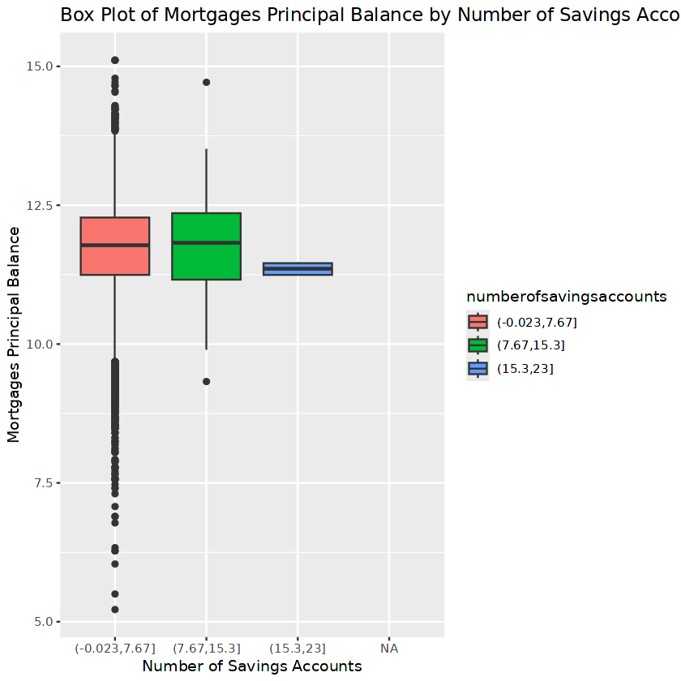

```r
# Box plot for numberofsavingsaccounts
ggplot(df_discretized, aes(x = numberofsavingsaccounts, y = log(mortgagesprincipalbalance), fill = numberofsavingsaccounts)) +
  geom_boxplot() +
  labs(title = "Box Plot of Mortgages Principal Balance by Number of Savings Accounts",
       x = "Number of Savings Accounts",
       y = "Mortgages Principal Balance")
```

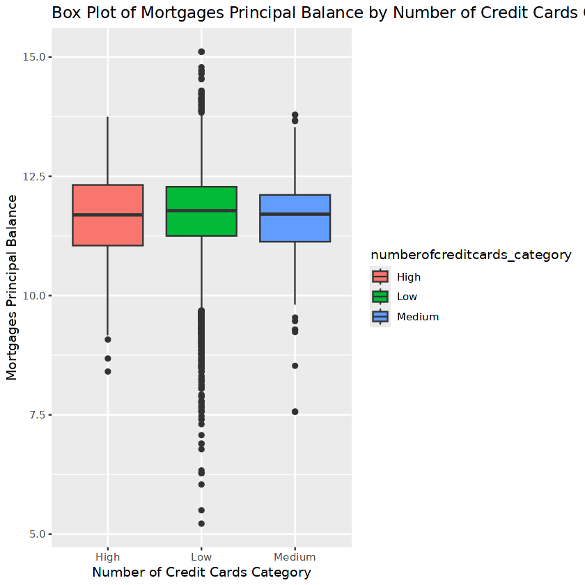

```r
# Box plot for numberofcreditcards_category
ggplot(df_discretized, aes(x = numberofcreditcards_category, y = log(mortgagesprincipalbalance), fill = numberofcreditcards_category)) +
  geom_boxplot() +
  labs(title = "Box Plot of Mortgages Principal Balance by Number of Credit Cards Category",
       x = "Number of Credit Cards Category",
       y = "Mortgages Principal Balance")
```

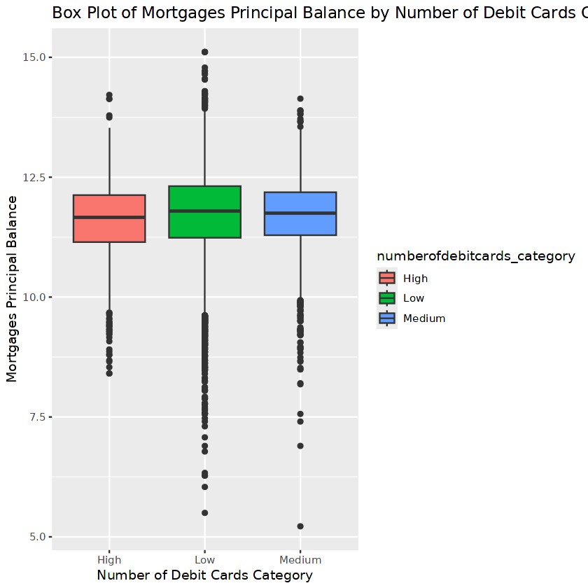

```r
# Save current warning behavior
old_warning <- getOption("warn")

# Temporarily suppress warnings
options(warn = -1)

# Box plot for numberofdebitcards_category
ggplot(df_discretized, aes(x = numberofdebitcards_category, y = log(mortgagesprincipalbalance), fill = numberofdebitcards_category)) +
  geom_boxplot() +
  labs(title = "Box Plot of Mortgages Principal Balance by Number of Debit Cards Category",
       x = "Number of Debit Cards Category",
       y = "Mortgages Principal Balance")

# Restore original warning behavior
options(warn = old_warning)
```